# Ratio of Two Poisson Distributed Variables

Alexander Ondrus

2024-10-15

## Distribution of Poisson Average

We use Bayesian inference to construct credible intervals for the average parameter of a Poisson distributed variable.

$$h(\lambda | x) = \frac{g(\lambda) \cdot
f(x | \lambda)}{\int_0^\infty g(t) f(x | t) dt}$$

Assume a single observation with a count of $a$. Here I use an improper constant prior of 1.

$$\begin{matrix}
h(\lambda | a) &=& \frac{1 \cdot f(a | \lambda)}{\int_0^\infty
1\cdot f(a | t) dt} \\
&=& \frac{e^{-\lambda \frac{\lambda^a}{a!}}}{\int_0^\infty
e^{-t}\frac{t^a}{a!} dt} \\
&=& \frac{e^{-\lambda} \lambda^a}{\Gamma(a + 1)} \\
&=& \frac{1^{a + 1}}{\Gamma(a+1)} \lambda^{(a+1)-1} e^{-1 \cdot
\lambda}
\end{matrix}$$

Thus, a single observation of a count of $a$ for a Poisson-distributed variable gives a $\mathrm{Gamma}(a + 1, 1)$ posterior distribution for $\lambda$.

### Examples

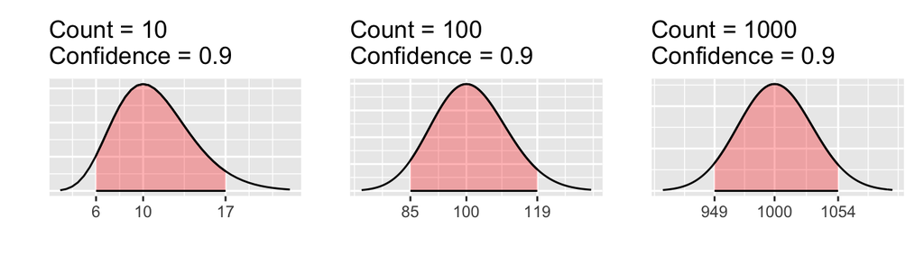

## Ratio of Poisson Variables

Assuming $X \sim \mathrm{Poisson}(\lambda_1)$ and $Y \sim \mathrm{Poisson}(\lambda_2)$ we can construct credible intervals $a_1 \leq \lambda_1 \leq a_2$ and $b_1 \leq \lambda_2 \leq b_2$. The simplest interval for for $\frac{\lambda_1}{\lambda_2}$ is then $\frac{a_1}{b_2} \leq \frac{\lambda_1}{\lambda_2} \leq \frac{a_2}{b_1}$. We use the following function to construct this interval:

```r
poisson_ratio <- function(count1, count2, confidence){
  prob_vector <- c((1 - confidence) / 2, 1 - ((1 - confidence)/2))
  count1_bounds <- qgamma(
    prob_vector,
    shape = count1 + 1,
    rate = 1
  )
  count2_bounds <- qgamma(
    prob_vector,
    shape = count2 + 1,
    rate = 1
  )

  return_list =
    list(
    "Numerator Bounds" = count1_bounds,
    "Denominator Bounds" = count2_bounds,
    "Ratio Bounds" = c(
      min(count1_bounds) / max(count2_bounds),
      max(count1_bounds) / min(count2_bounds)
    )
  )

  return(return_list)
}
```

### Example Calculation

Suppose that a given process observed a count of 1354 last year and after going through a dramatic change and observed a count of 609 this year. Construct a 90% credible interview for the ratio of true average observations from one year to the next.

First, we visualize the credible intervals for each average separately:

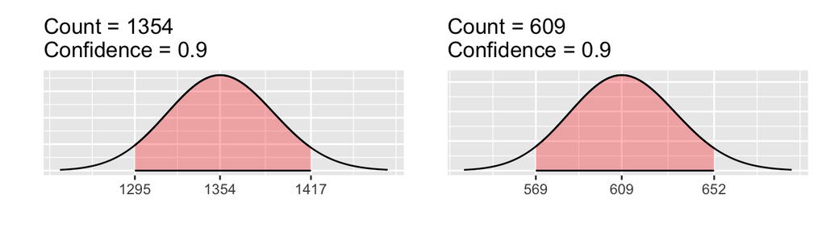

Using the function defined above we see that the 90% credible interval for the ratio of the average to be 0.402 $\leq$ 0.45 $\leq$ 0.503.